# Modelos Locales

Teresa Ortiz

27 de enero de 2015

En esta parte veremos cómo construir los modelos locales que corresponden a factores en la regla del producto para factorizaciones sobre DAGs, y veremos cómo usar datos para ajustar sus parámetros.

### Tablas de probabilidad condicional

En primer lugar, recordemos que siempre podemos hacer representaciones tabulares para la condicional de cada variable dado sus padres: $P(X|Pa(X)),$ donde establecemos, para cada combinación de valores de las variables en $Pa(X)$, una distribución sobre $X$ tal que $\sum_x P(X=x|Pa(X))=1.$

**Ejemplo.** En el ejemplo de la clase anterior construimos directamente las condicionales de llueve (no condicional), regar (no condicional) y mojado dado llueve y regar:

```r
llueve <- c('Sí','No')
regar <- c('Prendido', 'Apagado')
p_llueve <- data.frame(llueve = llueve, prob.l = c(0.1, 0.9))
p_llueve
```

```
##   llueve prob.l
## 1     Sí    0.1
## 2     No    0.9
```

```r
p_regar <- data.frame(regar = regar, prob.r = c(0.2, 0.8))
p_regar
```

```
##      regar prob.r
## 1 Prendido    0.2
## 2  Apagado    0.8
```

```r
mojado <- c('Mojado','Seco')
niveles <- expand.grid(llueve = llueve, regar = regar, mojado = mojado)
p_mojado_lr <- data.frame(niveles, prob_m = NA)
p_mojado_lr$prob_m[1:4] <- c(0.97, 0.9, 0.8, 0.01)
p_mojado_lr$prob_m[5:8]<- 1 - p_mojado_lr$prob_m[1:4]
p_mojado_lr
```

```
##   llueve    regar mojado prob_m
## 1     Sí Prendido Mojado   0.97
## 2     No Prendido Mojado   0.90
## 3     Sí  Apagado Mojado   0.80
## 4     No  Apagado Mojado   0.01
## 5     Sí Prendido   Seco   0.03
## 6     No Prendido   Seco   0.10
## 7     Sí  Apagado   Seco   0.20
## 8     No  Apagado   Seco   0.99
```

Representar los modelos locales de esta forma tiene una desventaja potencial: Esta representación **no explota ninguna regularidad que pueda existir en la condicional**, así que cuando la variable respuesta depende de muchas variables hay muchos parámetros por estimar individualmente (cada probabilidad condicional, menos uno). Esto puede ser difícil de ajustar con datos o demasiado engorroso de elicitar para un experto.

Ejemplos de regularidades:

- Si riegan, entonces el piso va a estar mojado sin importar si llueve o no. (no es necesario un parámetro separado para llueve/no llueve)
- La probabilidad de conseguir ser aceptado en una universidad depende de la calidad de las cartas de recomendación del profesor A, el profesor B, y de la carta que decida enviar el solicitante. Si un estudiante escoge la carta de recomendación del profesor A para pedir trabajo, la probabilidad de conseguir el trabajo no depende de la carta del profesor B. (dado que escogió la carta A, basta dar la tabla de probabilidades aceptación-calidad de carta A, sin importar la calidad de la carta B).
- La probabilidad de una categoría sigue un modelo logístico sin interacciones entre las variables de entrada (padres) (no es necesario tener parámetros para interacciones entre las variables de entrada).

En todos estos casos, podemos reducir el número de parámetros a estimar y obtener una representación más simple, siempre y cuando nuestros modelos más simples ajusten a los datos.

La idea importante es que para especificar las probabilidades condicionales no es necesario dar una tabla completa explícitamente. Podemos tener reglas o modelos simples de las cuales podamos calcular cualquier probabilidad condicional que nos interese.

### Estimación directa por máxima verosimilitud

Cuando usamos datos para estimar los modelos locales, si no hacemos supuestos sobre la estructura de los modelos locales, podemos usar máxima verosimilitud para hacer la estimación.

Para estimar $P(X_i=x|X_1=x_1,\ldots, X_k=x_k)$

utilizamos simplemente $\frac{N(X_i=x,X_1=x_1,\ldots, X_k=x_k)}{N(X_1=x_1,\ldots, X_k=x_k)}.$

Nótese que cuando hay muchas variables de entrada/relativamente pocos datos, esta estimación puede ser muy ruidosa (pocos casos en el denominador), o simplemente infactible. Para modelos simples funciona razonablemente bien.

Una solución (relacionada con un modelo bayesiano) es suavizar los conteos con $\frac{N(X_i=x,X_1=x_1,\ldots, X_k=x_k)+\alpha_x}{N(X_1=x_1,\ldots, X_k=x_k)+\alpha},$ donde $\sum_x \alpha_x=\alpha$.

**Ejemplo.** Consideramos el siguiente ejemplo de datos de la ENIGH 2010 (una observación por hogar, características de hogares y sus habitantes):

```r
library(bnlearn)
library(plyr)
library(dplyr)
load(file = 'datos/dat_ing.Rdata')
dat_ing$marg <- factor(as.character(dat_ing$marg))

# creamos una base únicamente con variables de interés
dat_ing_f <- select(dat_ing, tam_loc, marg, decil, nivelaprob, vehiculo,
                    drenaje, pisos, sexojefe)

black <- data.frame(
  form = c('drenaje', 'nivelaprob', 'decil', 'decil', 'nivelaprob'),
  to = c('decil', 'sexojefe', 'nivelaprob', 'tam_loc', 'marg'))

net_enigh <- hc(dat_ing_f,  score = 'aic', blacklist = black)
net_enigh
```

```
##
##   Bayesian network learned via Score-based methods
##
##   model:
##    [tam_loc][marg|tam_loc][sexojefe|tam_loc]
##    [nivelaprob|tam_loc:marg:sexojefe][decil|marg:nivelaprob]
##    [vehiculo|decil:nivelaprob:sexojefe][drenaje|tam_loc:marg:decil]
##    [pisos|decil:drenaje]
##   nodes:                                 8
##   arcs:                                  15
##     undirected arcs:                     0
##     directed arcs:                       15
##   average markov blanket size:           4.50
##   average neighbourhood size:            3.75
##   average branching factor:              1.88
##
##   learning algorithm:                    Hill-Climbing
##   score:                                 AIC (disc.)
##   penalization coefficient:              1
##   tests used in the learning procedure:  126
##   optimized:                             TRUE
```

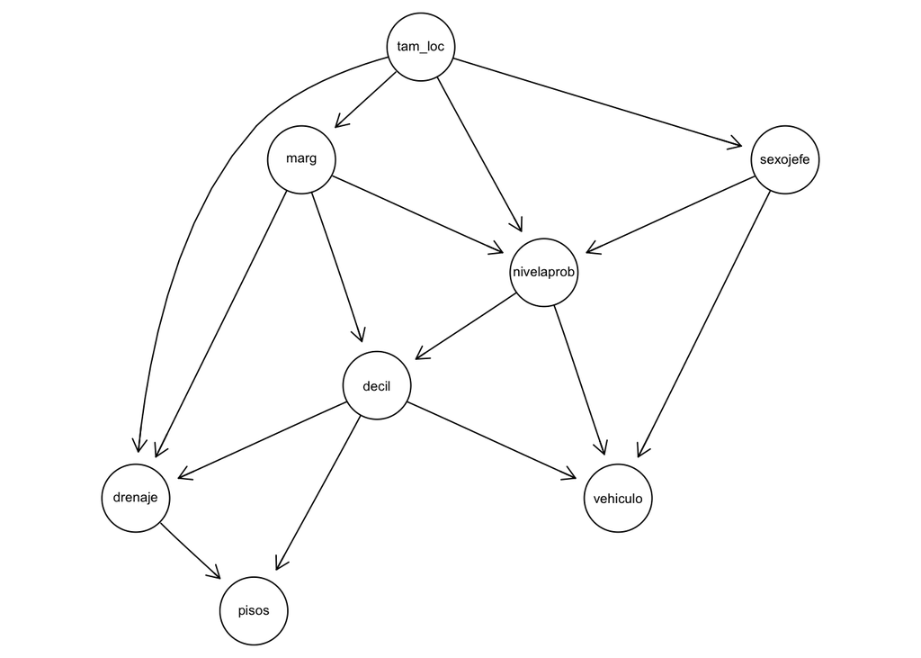

```r
fit_enigh_mle <- bn.fit(net_enigh, data = dat_ing_f, method = 'mle')
#write.net("./salidas/enigh_mle_1.net", fit_enigh_mle)
graphviz.plot(net_enigh)
```

La estimación por máxima verosimilitud para la condicional de marginación dado tamaño de localidad es

```r
fit_enigh_mle[['marg']]
```

```
##
##   Parameters of node marg (multinomial distribution)
##
## Conditional probability table:
##
##           tam_loc
## marg       100 mil o mas De 15 mil a 100 mil De 2500 a 15 mil
##   Alto             0.000               0.150            0.293
##   Bajo             0.070               0.292            0.229
##   Medio            0.037               0.201            0.236
##   Muy alto         0.000               0.023            0.092
##   Muy bajo         0.893               0.334            0.149
##           tam_loc
## marg       Menos de 2500
##   Alto             0.315
##   Bajo             0.143
##   Medio            0.214
##   Muy alto         0.219
##   Muy bajo         0.109
```

Que es simplemente (máxima verosimilitud):

```r
tab_1 <- table(dat_ing$marg, dat_ing$tam_loc)
tab_1
```

```
##
##            100 mil o mas De 15 mil a 100 mil De 2500 a 15 mil
##   Alto                 0                 769             1018
##   Bajo               970                1496              794
##   Medio              515                1031              820
##   Muy alto             0                 120              321
##   Muy bajo         12377                1715              518
##
##            Menos de 2500
##   Alto              2173
##   Bajo               983
##   Medio             1472
##   Muy alto          1506
##   Muy bajo           754
```

```r
tab_2 <- prop.table(tab_1, margin = 2)
tab_2
```

```
##
##            100 mil o mas De 15 mil a 100 mil De 2500 a 15 mil
##   Alto             0.000               0.150            0.293
##   Bajo             0.070               0.292            0.229
##   Medio            0.037               0.201            0.236
##   Muy alto         0.000               0.023            0.092
##   Muy bajo         0.893               0.334            0.149
##
##            Menos de 2500
##   Alto             0.315
##   Bajo             0.143
##   Medio            0.214
##   Muy alto         0.219
##   Muy bajo         0.109
```

En este ejemplo, donde los denominadores son relativamente grandes, no es necesario hacer ningún suavizamiento. Sin embargo, podemos utilizar suavizamiento de conteos de la siguiente forma (*iss* es *imaginary sample size*).

```r
fit_enigh_b <- bn.fit(net_enigh, data = dat_ing_f, method = 'bayes', iss = 100)
fit_enigh_b[['marg']]
```

```
##
##   Parameters of node marg (multinomial distribution)
##
## Conditional probability table:
##
##           tam_loc
## marg       100 mil o mas De 15 mil a 100 mil De 2500 a 15 mil
##   Alto           0.00036             0.15012          0.29262
##   Bajo           0.07021             0.29112          0.22855
##   Medio          0.03745             0.20093          0.23598
##   Muy alto       0.00036             0.02424          0.09325
##   Muy bajo       0.89163             0.33359          0.14960
##           tam_loc
## marg       Menos de 2500
##   Alto           0.31506
##   Bajo           0.14292
##   Medio          0.21366
##   Muy alto       0.21857
##   Muy bajo       0.10979
```

```r
prop.table(tab_1 + 100 / (4 * 5), margin = 2)
```

```
##
##            100 mil o mas De 15 mil a 100 mil De 2500 a 15 mil
##   Alto           0.00036             0.15012          0.29262
##   Bajo           0.07021             0.29112          0.22855
##   Medio          0.03745             0.20093          0.23598
##   Muy alto       0.00036             0.02424          0.09325
##   Muy bajo       0.89163             0.33359          0.14960
##
##            Menos de 2500
##   Alto           0.31506
##   Bajo           0.14292
##   Medio          0.21366
##   Muy alto       0.21857
##   Muy bajo       0.10979
```

Mayor suavizamiento regulariza más los conteos. Para muestras más chicas, es posible que sea necesario escoger suavizamientos más chicos.

**Ejemplo.** Repetiremos el ejercicio con una muestra chica para ver cómo puede mejorar nuestra estimación el suavizamiento.

```r
library(ggplot2)
library(tidyr)

set.seed(282095)

# tomamos una muestra de tamaño 50
dat_ing_muestra <- sample_n(dat_ing_f, 50)

# veamos la tabla cruda
table(dat_ing_muestra$marg, dat_ing_muestra$tam_loc)
```

```
##
##            100 mil o mas De 15 mil a 100 mil De 2500 a 15 mil
##   Alto                 0                   2                2
##   Bajo                 0                   4                3
##   Medio                0                   2                0
##   Muy alto             0                   0                0
##   Muy bajo            25                   5                0
##
##            Menos de 2500
##   Alto                 2
##   Bajo                 0
##   Medio                2
##   Muy alto             2
##   Muy bajo             1
```

```r
# usamos máxima verosimilitud
fit_enigh_1 <- bn.fit(net_enigh, data = dat_ing_muestra, method='mle')
probs_est_mle <- data.frame(fit_enigh_1[['marg']]$prob)
names(probs_est_mle)[3] <- 'mle'
probs_est_mle
```

```
##        marg             tam_loc  mle
## 1      Alto       100 mil o mas 0.00
## 2      Bajo       100 mil o mas 0.00
## 3     Medio       100 mil o mas 0.00
## 4  Muy alto       100 mil o mas 0.00
## 5  Muy bajo       100 mil o mas 1.00
## 6      Alto De 15 mil a 100 mil 0.15
## 7      Bajo De 15 mil a 100 mil 0.31
## 8     Medio De 15 mil a 100 mil 0.15
## 9  Muy alto De 15 mil a 100 mil 0.00
## 10 Muy bajo De 15 mil a 100 mil 0.38
## 11     Alto    De 2500 a 15 mil 0.40
## 12     Bajo    De 2500 a 15 mil 0.60
## 13    Medio    De 2500 a 15 mil 0.00
## 14 Muy alto    De 2500 a 15 mil 0.00
## 15 Muy bajo    De 2500 a 15 mil 0.00
## 16     Alto       Menos de 2500 0.29
## 17     Bajo       Menos de 2500 0.00
## 18    Medio       Menos de 2500 0.29
## 19 Muy alto       Menos de 2500 0.29
## 20 Muy bajo       Menos de 2500 0.14
```

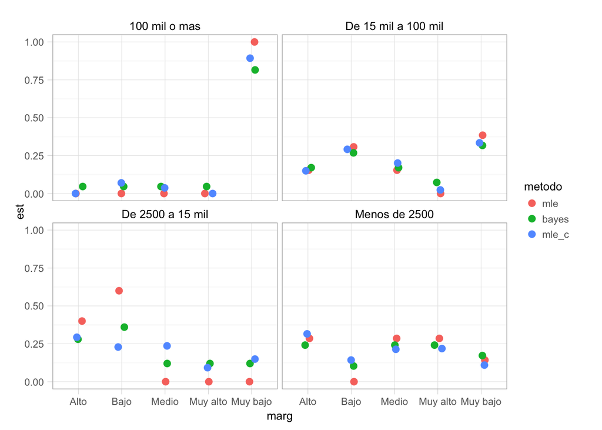

```r
# repetimos con suavizamiento
fit_enigh_2 <- bn.fit(net_enigh, data = dat_ing_muestra, method = 'bayes',
                      iss = 30)

probs_est_bayes <- data.frame(fit_enigh_2[['marg']]$prob)
names(probs_est_bayes)[3] <- 'bayes'
probs_1 <- join(probs_est_mle, probs_est_bayes)
# comparamos con las estimaciones que toman toda la base
tab_df <- data.frame(tab_2)
names(tab_df) <- c('marg', 'tam_loc', 'mle_c')

# las unimos a la base de datos probs_1
probs_2 <- join(probs_1, tab_df)
# creamos dos nuevas variables: método y estimación para poder graficar
probs_2_l <- gather(probs_2, metodo, est, mle, bayes, mle_c)

ggplot(probs_2_l, aes(x = marg, y = est, colour = metodo)) +
  geom_jitter(size=3,position=position_jitter(width=0.1, height=0))+
  facet_wrap(~ tam_loc)
```

Muy poca regularización (iss chica) típicamente no tiene efectos negativos (y conviene hacerla para evitar estimación de ceros), pero puede ser que demasiada regularización sí. Este parámetro puede ser escogido mediante validación cruzada, o desde un punto de vista bayesiano con información previa.

**Ejemplo.** Cuando los modelos son más complejos, la estimación de máxima verosimilitud puede ser muy mala, por ejemplo:

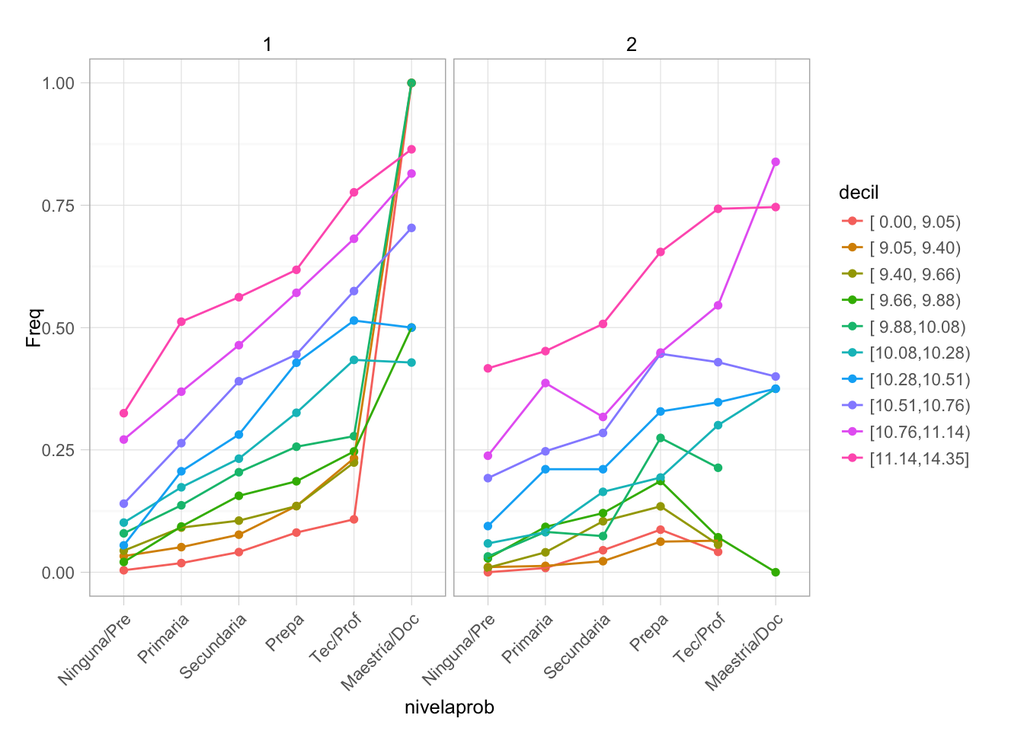

```r
mle_vehiculo <- data.frame(fit_enigh_mle[['vehiculo']]$prob)
mle_vehiculo_true <- filter(mle_vehiculo, vehiculo == 'TRUE',
                            nivelaprob!='No esp')

ggplot(mle_vehiculo_true, aes(x = nivelaprob, y = Freq, colour = decil,
                              group = decil)) +
  facet_wrap(~ sexojefe) +
  geom_point() +
  geom_line() +
  theme(axis.text.x = element_text(angle = 45, hjust = 1))
```

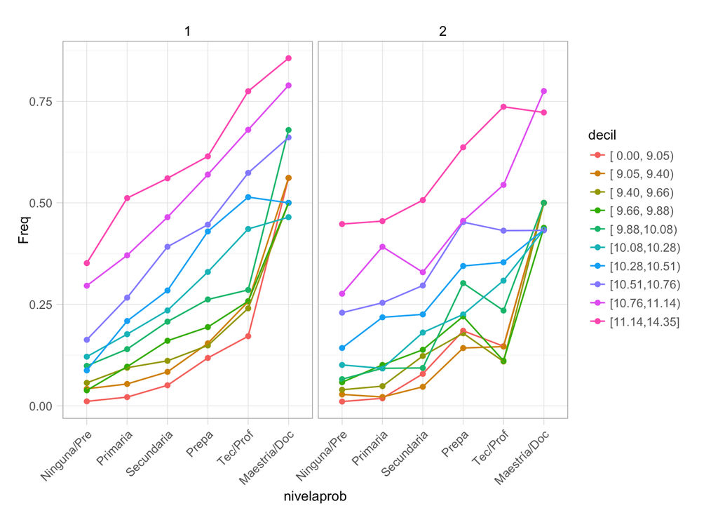

```r
fit_enigh_b <- bn.fit(net_enigh, data = dat_ing_f, method = 'bayes', iss = 1000)
b_vehiculo <- data.frame(fit_enigh_b[['vehiculo']]$prob)
b_vehiculo_true <- filter(b_vehiculo, vehiculo == 'TRUE',
                          nivelaprob!='No esp')

ggplot(b_vehiculo_true, aes(x = nivelaprob, y = Freq, colour = decil,
                              group = decil)) +
  facet_wrap(~ sexojefe) +
  geom_point() +
  geom_line() +
  theme(axis.text.x = element_text(angle = 45, hjust = 1))
```

### Probabilidades condicionales basadas en árboles

Podemos usar árboles de decisión para construir versiones compactas de probabilidades condicionales.

**Ejemplo.** Una carta de recomendación buena del profesor A da una probabilidad de 0.6 de conseguir el trabajo, mientras que una carta mala de 0.4. Para el profesor B, las probabilidades son 0.8 y 0.4. Consideramos la siguiente gráfica:

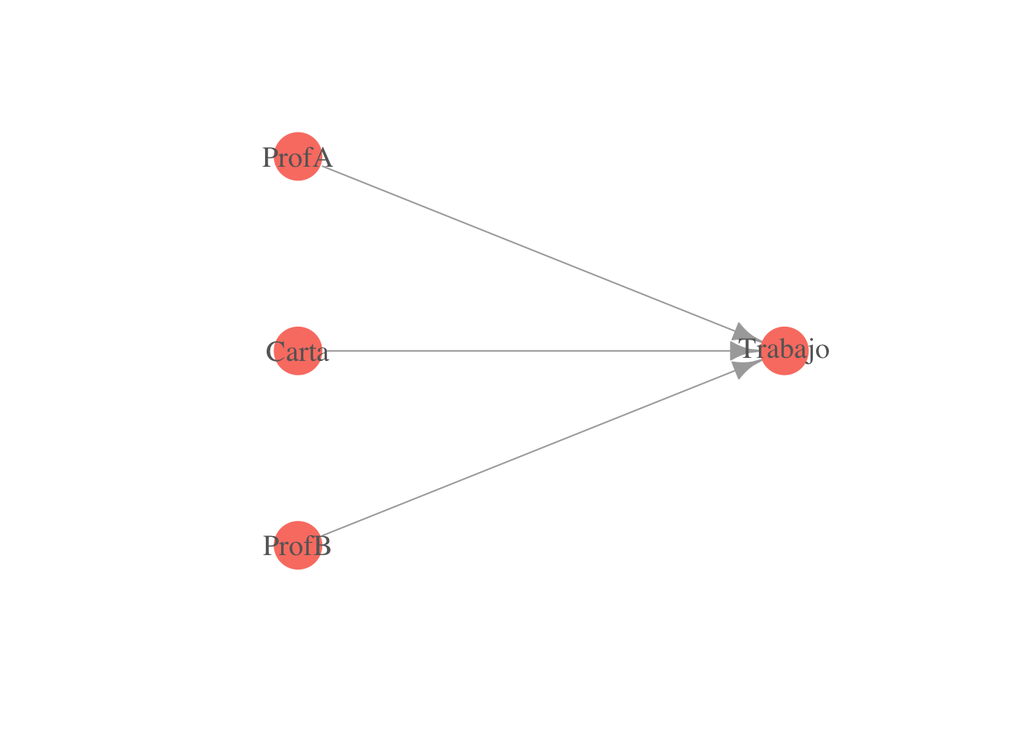

```r
library(igraph)
gr <- graph(c(1, 2, 3, 2, 4, 2))
plot(gr,
  vertex.label = c('ProfA', 'Trabajo', 'ProfB', 'Carta'),
  layout = matrix(c(0, 1, 0.6, 0, 0,-1, 0, 0), byrow = TRUE, ncol = 2),
  vertex.size = 20, vertex.color = 'salmon', vertex.label.cex = 1.2,
  vertex.label.color = 'gray40', vertex.frame.color = NA, asp = 0.8,
  edge.arrow.size = 1)
```

Representamos este escenario mediante un árbol:

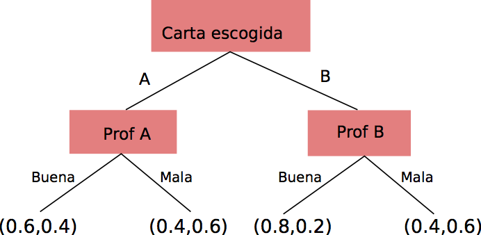

La estructura adicional que observamos es que cuando Carta=A, Trabajo es condicionalmente independiente de Prof B, y cuando Carta=B, Trabajo es condiconalmente independiente de ProfA. Esta es una independencia condicional distinta a las que vimos antes: dice que para **ciertos niveles de alguna variable, existen independencias condicionales entre otras variables**. Esto **no quiere decir** que dado Carta, Trabajo sea condicionalmente independiente de ProfA o ProfB. Otra manera de decir esto es que estos modelos locales pueden tener información de independencias condicionales en ciertos contextos (para valores particulares de las variables).

**Ejemplo**

```r
library(rpart)
library(rpart.plot)
library(rattle)
set.seed(22857)

# simulamos datos
prof_a <- sample(c('Buena', 'Mala', 'Mala'), 400, replace = T)
prof_b <- sample(c('Buena', 'Buena', 'Mala'), 400, replace = T)
carta <- sample(c('A', 'B'), 400, replace = T)
datos_sim <- data.frame(prof_a, prof_b, carta)

# describimos las probabilidades
probas <- datos_sim %>%
  distinct() %>%
  mutate(proba = (prof_a == 'Mala' & carta == 'A') * 0.4 +
           (prof_b == 'Mala' & carta == 'B') * 0.4 +
           (prof_a == 'Buena' & carta == 'A') * 0.6 +
           (prof_b == 'Buena' & carta == 'B') * 0.8)

probas
```

```
##   prof_a prof_b carta proba
## 1   Mala   Mala     B   0.4
## 2  Buena  Buena     B   0.8
## 3   Mala  Buena     B   0.8
## 4  Buena  Buena     A   0.6
## 5   Mala  Buena     A   0.4
## 6  Buena   Mala     B   0.4
## 7   Mala   Mala     A   0.4
## 8  Buena   Mala     A   0.6
```

```r
# finalmente simulamos si consigue el trabajo
datos_1 <- inner_join(datos_sim, probas)
datos_1$consigue <- rbinom(nrow(datos_1), size = 1, prob = datos_1$prob)

# usamos un árbol de decisión
arbol_1 <- rpart(consigue ~ prof_a + prof_b + carta, datos_1, method = 'class',
                 cp = 0)
printcp(arbol_1)
```

```
##
## Classification tree:
## rpart(formula = consigue ~ prof_a + prof_b + carta, data = datos_1,
##     method = "class", cp = 0)
##
## Variables actually used in tree construction:
## [1] carta  prof_a prof_b
##
## Root node error: 183/400 = 0
##
## n= 400
##
##   CP nsplit rel error xerror xstd
## 1  0      0         1      1    0
## 2  0      1         1      1    0
## 3  0      2         1      1    0
## 4  0      3         1      1    0
```

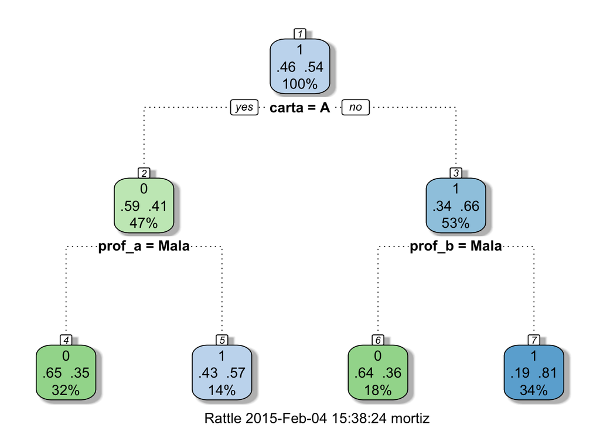

```r
fancyRpartPlot(arbol_1)
```

Aunque, sin más información, no hay garantía de recuperar la forma original.

```r
set.seed(46654)

prof_a <- sample(c('Buena', 'Mala', 'Mala'), 300, replace = T)
prof_b <- sample(c('Buena', 'Buena', 'Mala'), 300, replace = T)
carta <- sample(c('A', 'B'), 300, replace = T)
datos_sim <- data.frame(prof_a, prof_b, carta)

# describimos las probabilidades
probas <- datos_sim %>%
  distinct() %>%
  mutate(proba = (prof_a == 'Mala' & carta == 'A') * 0.4 +
           (prof_b == 'Mala' & carta == 'B') * 0.4 +
           (prof_a == 'Buena' & carta == 'A') * 0.6 +
           (prof_b == 'Buena' & carta == 'B') * 0.8)

# finalmente simulamos si consigue el trabajo
datos_1 <- inner_join(datos_sim, probas)
datos_1$consigue <- rbinom(nrow(datos_1), size = 1, prob = datos_1$prob)

# usamos un árbol de decisión
arbol_2 <- rpart(consigue ~ prof_a + prof_b + carta, datos_1, method = 'class',
                 cp = 0)
printcp(arbol_2)
```

```
##
## Classification tree:
## rpart(formula = consigue ~ prof_a + prof_b + carta, data = datos_1,
##     method = "class", cp = 0)
##
## Variables actually used in tree construction:
## [1] carta  prof_a prof_b
##
## Root node error: 127/300 = 0
##
## n= 300
##
##   CP nsplit rel error xerror xstd
## 1  0      0         1      1    0
## 2  0      1         1      1    0
## 3  0      3         1      1    0
## 4  0      5         1      1    0
```

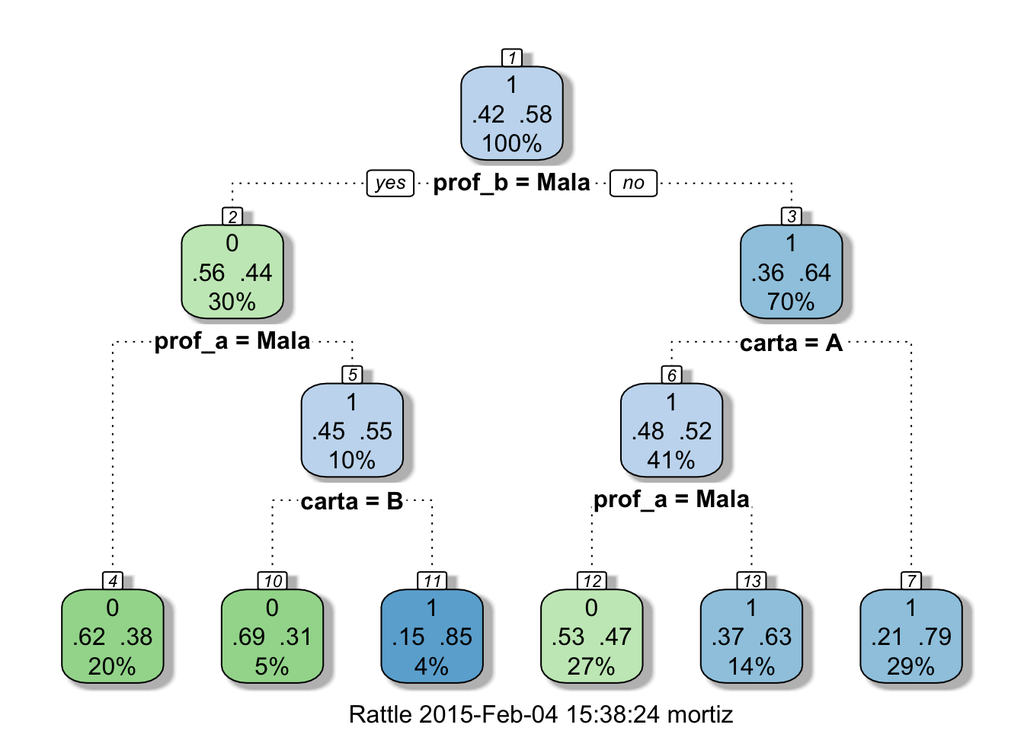

```r
fancyRpartPlot(arbol_2)
```

```r
# usamos un árbol de decisión
arbol_3 <- rpart(consigue ~ prof_a + prof_b + carta, datos_1, method = 'class',
                 cp = 0, cost = c(100, 100, 1))
printcp(arbol_3)
```

```
##
## Classification tree:
## rpart(formula = consigue ~ prof_a + prof_b + carta, data = datos_1,
##     method = "class", cost = c(100, 100, 1), cp = 0)
##
## Variables actually used in tree construction:
## [1] carta  prof_a prof_b
##
## Root node error: 127/300 = 0
##
## n= 300
##
##   CP nsplit rel error xerror xstd
## 1  0      0         1      1    0
## 2  0      3         1      1    0
```

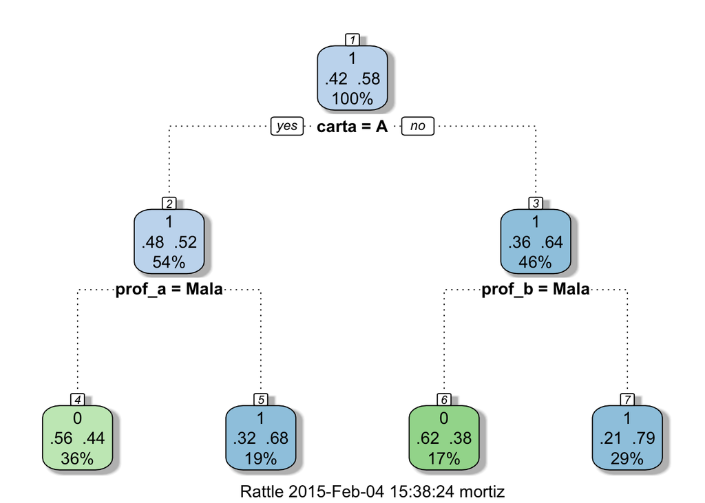

```r
fancyRpartPlot(arbol_3)
```

### Modelos lineales generalizados

Otra técnica es utilizar modelos logísticos multinomiales (o simplemente logístico cuando la respuesta tiene 2 niveles). La ventaja de este enfoque es que podemos controlar la complejidad del modelo a través de inclusión/exclusión de interacciones y regularización.

```r
net_enigh <- hc(dat_ing_f,  score='aic', blacklist = black)
net_enigh
```

```
##
##   Bayesian network learned via Score-based methods
##
##   model:
##    [tam_loc][marg|tam_loc][sexojefe|tam_loc]
##    [nivelaprob|tam_loc:marg:sexojefe][decil|marg:nivelaprob]
##    [vehiculo|decil:nivelaprob:sexojefe][drenaje|tam_loc:marg:decil]
##    [pisos|decil:drenaje]
##   nodes:                                 8
##   arcs:                                  15
##     undirected arcs:                     0
##     directed arcs:                       15
##   average markov blanket size:           4.50
##   average neighbourhood size:            3.75
##   average branching factor:              1.88
##
##   learning algorithm:                    Hill-Climbing
##   score:                                 AIC (disc.)
##   penalization coefficient:              1
##   tests used in the learning procedure:  126
##   optimized:                             TRUE
```

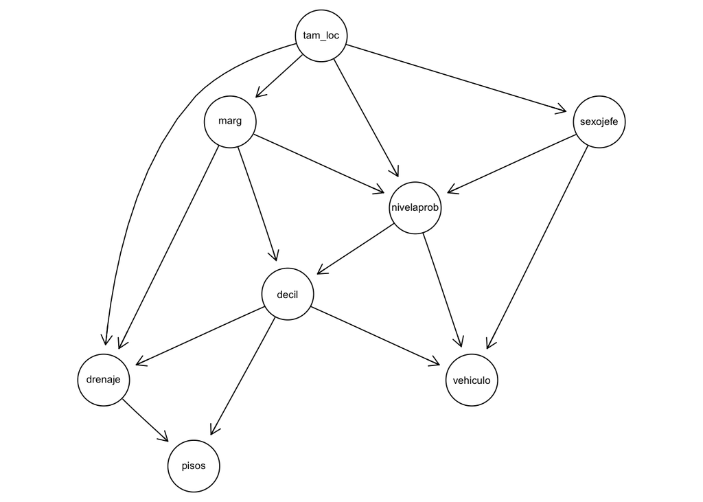

```r
fit_enigh <- bn.fit(net_enigh, data = dat_ing_f, method='mle')
graphviz.plot(net_enigh)
```

Nos interesa el nodo de posesión de vehículo dado decil, nivel aprobado del jefe de familia y sexo del jefe de familia. En este caso, utilizaremos un modelo logístico regularizado.

Los datos se ven como sigue:

```r
library(tidyr)
dat_res <- dat_ing_f %>%
  group_by(sexojefe, nivelaprob, decil, vehiculo) %>%
  dplyr::summarise(num = n()) %>%
  group_by(sexojefe, nivelaprob, decil) %>%
  mutate(total = sum(num)) %>%
  ungroup() %>%
  mutate(prop = num/total)
dat_res
```

```
## Source: local data frame [228 x 7]
##
##    sexojefe  nivelaprob         decil vehiculo num total  prop
## 1         1      No esp [10.08,10.28)     TRUE   1     1 1.000
## 2         1      No esp [10.51,10.76)     TRUE   1     1 1.000
## 3         1      No esp [11.14,14.35]     TRUE   2     2 1.000
## 4         1 Ninguna/Pre [ 0.00, 9.05)    FALSE 494   496 0.996
## 5         1 Ninguna/Pre [ 0.00, 9.05)     TRUE   2   496 0.004
## 6         1 Ninguna/Pre [ 9.05, 9.40)    FALSE 352   364 0.967
## 7         1 Ninguna/Pre [ 9.05, 9.40)     TRUE  12   364 0.033
## 8         1 Ninguna/Pre [ 9.40, 9.66)    FALSE 239   250 0.956
## 9         1 Ninguna/Pre [ 9.40, 9.66)     TRUE  11   250 0.044
## 10        1 Ninguna/Pre [ 9.66, 9.88)    FALSE 187   191 0.979
## ..      ...         ...           ...      ... ...   ...   ...
```

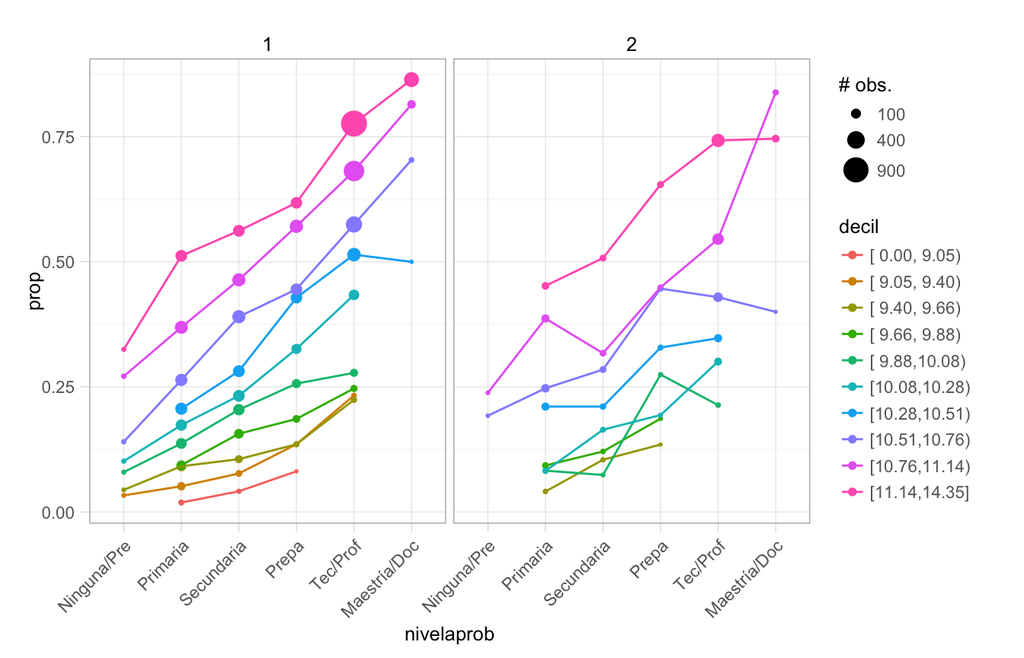

```r
dat_res_sub <- filter(dat_res, vehiculo==TRUE, num > 5)

cuadrado <- function(x){x ^ 2}
ggplot(dat_res_sub, aes(x = nivelaprob, y = prop, colour = decil,
  group = decil)) +
  geom_point(aes(size = sqrt(num))) +
  geom_line() +
  facet_wrap(~sexojefe) +
  scale_size_continuous("# obs.", labels = cuadrado) +
  theme(axis.text.x = element_text(angle = 45, hjust = 1))
```

Comenzamos con un modelo simple, con poca regularización:

```r
library(arm)

# vemos como se ve la variable vehículo
table(dat_ing$vehiculo)
```

```
##
## FALSE  TRUE
## 21813  7539
```

```r
dat_ing$vehiculo_l <- as.logical(dat_ing$vehiculo == "TRUE")
table(dat_ing$vehiculo_l)
```

```
##
## FALSE  TRUE
## 21813  7539
```

```r
# modelo con poca regularización
mod_1 <- bayesglm(vehiculo_l ~ sexojefe + nivelaprob + decil, data = dat_ing,
  prior.scale = 2.5, family = 'binomial')
display(mod_1)
```

```
## bayesglm(formula = vehiculo_l ~ sexojefe + nivelaprob + decil,
##     family = "binomial", data = dat_ing, prior.scale = 2.5)
##                        coef.est coef.se
## (Intercept)            -2.05     0.78
## sexojefe2              -0.42     0.04
## nivelaprobNinguna/Pre  -2.47     0.78
## nivelaprobPrimaria     -1.70     0.77
## nivelaprobSecundaria   -1.31     0.77
## nivelaprobPrepa        -0.90     0.77
## nivelaprobTec/Prof     -0.50     0.77
## nivelaprobMaestría/Doc  0.09     0.78
## decil[ 9.05, 9.40)      0.83     0.15
## decil[ 9.40, 9.66)      1.29     0.14
## decil[ 9.66, 9.88)      1.54     0.14
## decil[ 9.88,10.08)      1.87     0.14
## decil[10.08,10.28)      2.16     0.13
## decil[10.28,10.51)      2.50     0.13
## decil[10.51,10.76)      2.83     0.13
## decil[10.76,11.14)      3.27     0.13
## decil[11.14,14.35]      3.77     0.13
## ---
## n = 29352, k = 17
## residual deviance = 25155.9, null deviance = 33445.7 (difference = 8289.8)
```

```r
mod_1$aic
```

```
## [1] 25190
```

Agregamos las interacciones de sexojefe con decil.

```r
mod_2 <- bayesglm(vehiculo ~ sexojefe + nivelaprob + decil +
  sexojefe:decil, data = dat_ing, prior.scale = 2.5, family = 'binomial')
display(mod_2)
```

```
## bayesglm(formula = vehiculo ~ sexojefe + nivelaprob + decil +
##     sexojefe:decil, family = "binomial", data = dat_ing, prior.scale = 2.5)
##                              coef.est coef.se
## (Intercept)                  -2.02     0.78
## sexojefe2                    -0.58     0.32
## nivelaprobNinguna/Pre        -2.47     0.77
## nivelaprobPrimaria           -1.71     0.77
## nivelaprobSecundaria         -1.32     0.77
## nivelaprobPrepa              -0.90     0.77
## nivelaprobTec/Prof           -0.50     0.77
## nivelaprobMaestría/Doc        0.08     0.78
## decil[ 9.05, 9.40)            0.92     0.16
## decil[ 9.40, 9.66)            1.30     0.15
## decil[ 9.66, 9.88)            1.48     0.15
## decil[ 9.88,10.08)            1.87     0.15
## decil[10.08,10.28)            2.18     0.15
## decil[10.28,10.51)            2.46     0.14
## decil[10.51,10.76)            2.78     0.14
## decil[10.76,11.14)            3.23     0.14
## decil[11.14,14.35]            3.70     0.15
## sexojefe2:decil[ 9.05, 9.40) -0.69     0.42
## sexojefe2:decil[ 9.40, 9.66) -0.05     0.36
## sexojefe2:decil[ 9.66, 9.88)  0.29     0.35
## sexojefe2:decil[ 9.88,10.08) -0.04     0.34
## sexojefe2:decil[10.08,10.28) -0.04     0.34
## sexojefe2:decil[10.28,10.51)  0.24     0.33
## sexojefe2:decil[10.51,10.76)  0.24     0.33
## sexojefe2:decil[10.76,11.14)  0.21     0.33
## sexojefe2:decil[11.14,14.35]  0.38     0.33
## ---
## n = 29352, k = 26
## residual deviance = 25130.9, null deviance = 33445.7 (difference = 8314.7)
```

```r
mod_2$aic
```

```
## [1] 25183
```

Agregamos ahora la interacción sexojefe con nivelaprob, notemos que incluir esta interacción incrementa considerablemente el aic,

```r
mod_3 <- bayesglm(vehiculo ~ sexojefe + nivelaprob + decil +
  sexojefe:nivelaprob + decil:nivelaprob, data = dat_ing,
  prior.scale = 2.5, family = 'binomial')
display(mod_3)
```

```
## bayesglm(formula = vehiculo ~ sexojefe + nivelaprob + decil +
##     sexojefe:nivelaprob + decil:nivelaprob, family = "binomial",
##     data = dat_ing, prior.scale = 2.5)
##                                           coef.est coef.se
## (Intercept)                               -1.74     0.82
## sexojefe2                                 -0.35     0.95
## nivelaprobNinguna/Pre                     -3.48     0.89
## nivelaprobPrimaria                        -2.24     0.83
## nivelaprobSecundaria                      -1.29     0.84
## nivelaprobPrepa                           -0.65     0.86
## nivelaprobTec/Prof                        -0.46     0.88
## nivelaprobMaestría/Doc                     1.14     1.09
## decil[ 9.05, 9.40)                         0.91     1.00
## decil[ 9.40, 9.66)                         0.97     1.03
## decil[ 9.66, 9.88)                         0.98     0.97
## decil[ 9.88,10.08)                         1.75     0.99
## decil[10.08,10.28)                         2.00     0.89
## decil[10.28,10.51)                         1.79     0.96
## decil[10.51,10.76)                         2.46     0.89
## decil[10.76,11.14)                         2.66     0.96
## decil[11.14,14.35]                         3.30     0.88
## sexojefe2:nivelaprobNinguna/Pre            0.07     0.96
## sexojefe2:nivelaprobPrimaria               0.05     0.95
## sexojefe2:nivelaprobSecundaria            -0.13     0.95
## sexojefe2:nivelaprobPrepa                  0.14     0.95
## sexojefe2:nivelaprobTec/Prof              -0.20     0.95
## sexojefe2:nivelaprobMaestría/Doc          -0.28     0.97
## nivelaprobNinguna/Pre:decil[ 9.05, 9.40)   0.73     1.08
## nivelaprobPrimaria:decil[ 9.05, 9.40)      0.01     1.01
## nivelaprobSecundaria:decil[ 9.05, 9.40)   -0.47     1.02
## nivelaprobPrepa:decil[ 9.05, 9.40)        -0.46     1.05
## nivelaprobTec/Prof:decil[ 9.05, 9.40)     -0.06     1.07
## nivelaprobMaestría/Doc:decil[ 9.05, 9.40)  1.16     1.90
## nivelaprobNinguna/Pre:decil[ 9.40, 9.66)   0.95     1.11
## nivelaprobPrimaria:decil[ 9.40, 9.66)      0.60     1.05
## nivelaprobSecundaria:decil[ 9.40, 9.66)    0.00     1.05
## nivelaprobPrepa:decil[ 9.40, 9.66)        -0.39     1.08
## nivelaprobTec/Prof:decil[ 9.40, 9.66)     -0.19     1.09
## nivelaprobMaestría/Doc:decil[ 9.40, 9.66)  0.00     2.50
## nivelaprobNinguna/Pre:decil[ 9.66, 9.88)   0.59     1.08
```

[output cut: 29 more lines]

```
## nivelaprobNinguna/Pre:decil[10.76,11.14)   1.61     1.04
## nivelaprobPrimaria:decil[10.76,11.14)      0.87     0.98
## nivelaprobSecundaria:decil[10.76,11.14)    0.20     0.98
## nivelaprobPrepa:decil[10.76,11.14)        -0.01     1.00
## nivelaprobTec/Prof:decil[10.76,11.14)      0.30     1.02
## nivelaprobMaestría/Doc:decil[10.76,11.14) -0.32     1.22
## nivelaprobNinguna/Pre:decil[11.14,14.35]   1.33     0.98
## nivelaprobPrimaria:decil[11.14,14.35]      0.75     0.90
## nivelaprobSecundaria:decil[11.14,14.35]    0.03     0.90
## nivelaprobPrepa:decil[11.14,14.35]        -0.35     0.93
## nivelaprobTec/Prof:decil[11.14,14.35]      0.23     0.94
## nivelaprobMaestría/Doc:decil[11.14,14.35] -0.87     1.14
## ---
## n = 29352, k = 77
## residual deviance = 25080.3, null deviance = 33445.7 (difference = 8365.4)
```

```r
mod_3$aic
```

```
## [1] 25234
```

Ahora vemos las probabilidades estimadas del modelo 2:

```r
# creamos una base con todas las combinaciones de niveles de las variables
grid_1 <- expand.grid(list(sexojefe = unique(dat_ing$sexojefe),
  nivelaprob = unique(dat_ing$nivelaprob),
  decil = unique(dat_ing$decil)), stringsAsFactors = FALSE)

# calculamos la probabilidad para cada caso usando predict
grid_1$prob <- predict(mod_2, grid_1, type = 'response')
grid_1$metodo <- "logística"

# obtenemos la siguietnte base de datos
head(grid_1)
```

```
##   sexojefe   nivelaprob         decil  prob    metodo
## 1        1        Prepa [ 0.00, 9.05) 0.051 logística
## 2        2        Prepa [ 0.00, 9.05) 0.029 logística
## 3        1     Primaria [ 0.00, 9.05) 0.024 logística
## 4        2     Primaria [ 0.00, 9.05) 0.013 logística
## 5        1 Maestría/Doc [ 0.00, 9.05) 0.126 logística
## 6        2 Maestría/Doc [ 0.00, 9.05) 0.075 logística
```

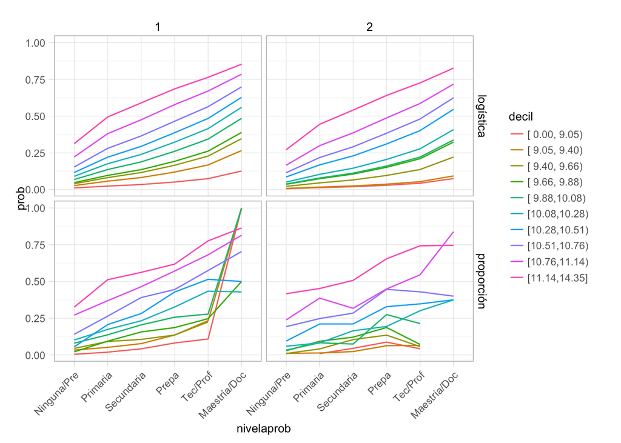

```r
# y unimos con proporciones (MLE) para comparar
dat_res$metodo <- "proporción"
probs_est <- filter(dat_res, vehiculo == TRUE) %>%
  dplyr::select(sexojefe, nivelaprob, decil, prob = prop, metodo) %>%
  rbind(grid_1) %>%
  filter(nivelaprob != "No esp")

ggplot(probs_est, aes(x = nivelaprob, y = prob, colour = decil, group = decil)) +
  geom_line() +
  facet_grid(metodo ~ sexojefe) +
  theme(axis.text.x=element_text(angle = 45, hjust = 1))
```

Y podemos incluir intervalos de probabilidad.

```r
# realizamos simulaciones de los parámetros
sims <- sim(mod_2, 100)
str(sims)
```

```
## Formal class 'sim' [package "arm"] with 2 slots
##   ..@ coef : num [1:100, 1:26] -2.949 -2.458 0.161 -2.291 -1.176 ...
##   .. ..- attr(*, "dimnames")=List of 2
##   .. .. ..$ : NULL
##   .. .. ..$ : chr [1:26] "(Intercept)" "sexojefe2" "nivelaprobNinguna/Pre" "nivelaprobPrimaria" ...
##   ..@ sigma: num [1:100] 1 1 1 1 1 1 1 1 1 1 ...
```

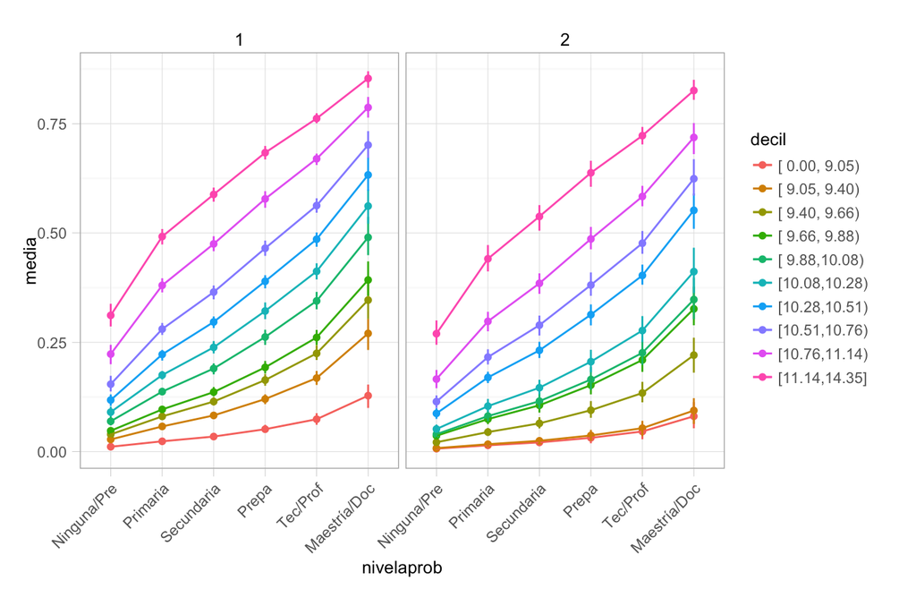

```r
# y los utilizamos en la función predict
mod_2$coefficients <- sims@coef[3, ]
grid_1$prob <- predict(mod_2, grid_1, type='response')

# repetimos este procedimiento para cada conjunto de coeficientes simulados
dat_sims <- ldply(1:100, function(i){
  mod_2$coefficients <- sims@coef[i, ]
  grid_1$prob <- predict(mod_2, grid_1, type='response')
  grid_1$sim_no <- i
  grid_1
})

# calculamos los cuantiles a partir de las probabilidades simuladas
dat_sims_1 <- dat_sims %>%
  group_by(sexojefe, nivelaprob, decil) %>%
  summarise(
    media = mean(prob),
    q_10 = quantile(prob, 0.1),
    q_90 = quantile(prob,0.9)
    ) %>%
  filter(nivelaprob != 'No esp')

ggplot(dat_sims_1, aes(x = nivelaprob, y = media, colour = decil, group = decil,
  ymin = q_10, ymax = q_90)) +
  geom_point()+geom_line() +
  facet_wrap(~ sexojefe) +
  geom_linerange()+
  theme(axis.text.x = element_text(angle = 45, hjust = 1))
```

Finalmente checamos la calibración del modelo con los datos (las probabilidades estimadas reflejan probabilidades empíricas:

```r
library(Hmisc) # función cut2
```

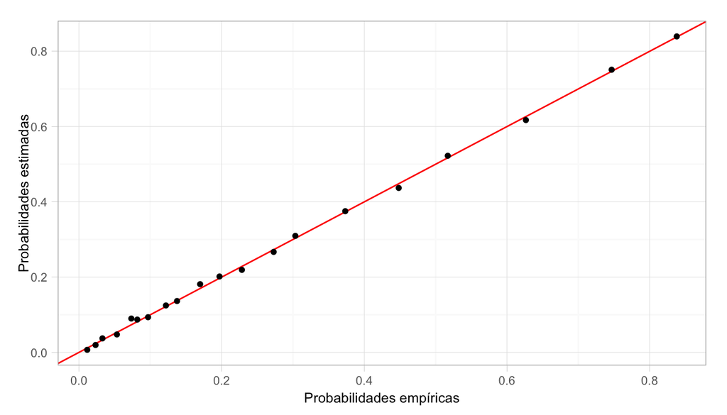

```r
mod_2 <- bayesglm(vehiculo ~ sexojefe + nivelaprob + decil +
  sexojefe:decil, data = dat_ing, prior.scale = 2.5, family = 'binomial')

# predecimos para las observaciones en la base de datos
dat_ing$prob <- predict(mod_2, type = 'response')

dat_cal <- dat_ing_f %>%
  mutate(
    prob = predict(mod_2, type = 'response'),
    grupo_prob = cut2(prob, g = 20, levels.mean = TRUE)
      ) %>%
  group_by(grupo_prob) %>%
  summarise(
    num = n(),
    total_vehiculo = sum(vehiculo == TRUE)
    ) %>%
  mutate(
    prob_emp = total_vehiculo / num,
    grupo_prob_n = as.numeric(as.character(grupo_prob))
    )

ggplot(dat_cal, aes(x = grupo_prob_n, y = prob_emp)) +
  geom_abline(intercept = 0, slope = 1, color = "red") +
  geom_point() +
  xlab("Probabilidades empíricas") +
  ylab("Probabilidades estimadas")
```

Y obtenemos la tabla de la probabilidad condicional,

```r
grid_1
```

```
##     sexojefe   nivelaprob         decil   prob    metodo
## 1          1        Prepa [ 0.00, 9.05) 0.0507 logística
## 2          2        Prepa [ 0.00, 9.05) 0.0203 logística
## 3          1     Primaria [ 0.00, 9.05) 0.0248 logística
## 4          2     Primaria [ 0.00, 9.05) 0.0098 logística
## 5          1 Maestría/Doc [ 0.00, 9.05) 0.1311 logística
## 6          2 Maestría/Doc [ 0.00, 9.05) 0.0553 logística
## 7          1  Ninguna/Pre [ 0.00, 9.05) 0.0125 logística
## 8          2  Ninguna/Pre [ 0.00, 9.05) 0.0049 logística
## 9          1   Secundaria [ 0.00, 9.05) 0.0355 logística
## 10         2   Secundaria [ 0.00, 9.05) 0.0141 logística
## 11         1     Tec/Prof [ 0.00, 9.05) 0.0786 logística
## 12         2     Tec/Prof [ 0.00, 9.05) 0.0321 logística
## 13         1       No esp [ 0.00, 9.05) 0.5403 logística
## 14         2       No esp [ 0.00, 9.05) 0.3132 logística
```

[output cut: 126 more lines]

que incluimos a nuestro modelo local en la red:

```r
fit_enigh <- bn.fit(net_enigh, data = dat_ing_f, method = 'mle')
fit_enigh[['vehiculo']]
```

```
##
##   Parameters of node vehiculo (multinomial distribution)
##
## Conditional probability table:
##
## , , nivelaprob = No esp, sexojefe = 1
##
##         decil
## vehiculo [ 0.00, 9.05) [ 9.05, 9.40) [ 9.40, 9.66) [ 9.66, 9.88)
##    FALSE
##    TRUE
##         decil
## vehiculo [ 9.88,10.08) [10.08,10.28) [10.28,10.51) [10.51,10.76)
##    FALSE                      0.0000                      0.0000
##    TRUE                       1.0000                      1.0000
##         decil
## vehiculo [10.76,11.14) [11.14,14.35]
##    FALSE                      0.0000
##    TRUE                       1.0000
##
## , , nivelaprob = Ninguna/Pre, sexojefe = 1
##
##         decil
## vehiculo [ 0.00, 9.05) [ 9.05, 9.40) [ 9.40, 9.66) [ 9.66, 9.88)
##    FALSE        0.9960        0.9670        0.9560        0.9791
##    TRUE         0.0040        0.0330        0.0440        0.0209
##         decil
## vehiculo [ 9.88,10.08) [10.08,10.28) [10.28,10.51) [10.51,10.76)
##    FALSE        0.9205        0.8986        0.9451        0.8598
##    TRUE         0.0795        0.1014        0.0549        0.1402
##         decil
## vehiculo [10.76,11.14) [11.14,14.35]
##    FALSE        0.7288        0.6750
##    TRUE         0.2712        0.3250
##
## , , nivelaprob = Primaria, sexojefe = 1
##
##         decil
## vehiculo [ 0.00, 9.05) [ 9.05, 9.40) [ 9.40, 9.66) [ 9.66, 9.88)
##    FALSE        0.9813        0.9487        0.9088        0.9065
```

[output cut: 159 more lines]

```
##
## , , nivelaprob = Maestría/Doc, sexojefe = 2
##
##         decil
## vehiculo [ 0.00, 9.05) [ 9.05, 9.40) [ 9.40, 9.66) [ 9.66, 9.88)
##    FALSE                                                  1.0000
##    TRUE                                                   0.0000
##         decil
## vehiculo [ 9.88,10.08) [10.08,10.28) [10.28,10.51) [10.51,10.76)
##    FALSE                      0.6250        0.6250        0.6000
##    TRUE                       0.3750        0.3750        0.4000
##         decil
## vehiculo [10.76,11.14) [11.14,14.35]
##    FALSE        0.1613        0.2537
##    TRUE         0.8387        0.7463
```

```r
grid_1$vehiculo <- 'TRUE'
grid_2 <- grid_1
grid_2$prob <- 1-grid_2$prob
grid_2$vehiculo <- 'FALSE'
grid_3 <- rbind(grid_1, grid_2)
tab_veh <- xtabs(prob ~ vehiculo + decil + nivelaprob + decil + sexojefe,
  data = grid_3)
tab_veh
```

```
## , , nivelaprob = No esp, sexojefe = 1
##
##         decil
## vehiculo [ 0.00, 9.05) [ 9.05, 9.40) [ 9.40, 9.66) [ 9.66, 9.88)
##    FALSE        0.4597        0.2400        0.1918        0.1718
##    TRUE         0.5403        0.7600        0.8082        0.8282
##         decil
## vehiculo [ 9.88,10.08) [10.08,10.28) [10.28,10.51) [10.51,10.76)
##    FALSE        0.1116        0.0942        0.0681        0.0514
##    TRUE         0.8884        0.9058        0.9319        0.9486
##         decil
## vehiculo [10.76,11.14) [11.14,14.35]
##    FALSE        0.0348        0.0209
##    TRUE         0.9652        0.9791
##
## , , nivelaprob = Ninguna/Pre, sexojefe = 1
##
##         decil
## vehiculo [ 0.00, 9.05) [ 9.05, 9.40) [ 9.40, 9.66) [ 9.66, 9.88)
##    FALSE        0.9875        0.9670        0.9565        0.9506
##    TRUE         0.0125        0.0330        0.0435        0.0494
##         decil
## vehiculo [ 9.88,10.08) [10.08,10.28) [10.28,10.51) [10.51,10.76)
##    FALSE        0.9209        0.9060        0.8713        0.8340
##    TRUE         0.0791        0.0940        0.1287        0.1660
##         decil
## vehiculo [10.76,11.14) [11.14,14.35]
##    FALSE        0.7696        0.6645
##    TRUE         0.2304        0.3355
##
## , , nivelaprob = Primaria, sexojefe = 1
##
##         decil
## vehiculo [ 0.00, 9.05) [ 9.05, 9.40) [ 9.40, 9.66) [ 9.66, 9.88)
##    FALSE        0.9752        0.9358        0.9164        0.9055
##    TRUE         0.0248        0.0642        0.0836        0.0945
##         decil
## vehiculo [ 9.88,10.08) [10.08,10.28) [10.28,10.51) [10.51,10.76)
##    FALSE        0.8530        0.8278        0.7714        0.7147
##    TRUE         0.1470        0.1722        0.2286        0.2853
```

[output cut: 154 more lines]

```
##
## , , nivelaprob = Maestría/Doc, sexojefe = 2
##
##         decil
## vehiculo [ 0.00, 9.05) [ 9.05, 9.40) [ 9.40, 9.66) [ 9.66, 9.88)
##    FALSE        0.9447        0.9263        0.7489        0.6880
##    TRUE         0.0553        0.0737        0.2511        0.3120
##         decil
## vehiculo [ 9.88,10.08) [10.08,10.28) [10.28,10.51) [10.51,10.76)
##    FALSE        0.6643        0.5548        0.4773        0.4056
##    TRUE         0.3357        0.4452        0.5227        0.5944
##         decil
## vehiculo [10.76,11.14) [11.14,14.35]
##    FALSE        0.2697        0.1745
##    TRUE         0.7303        0.8255
```

```r
fit_enigh_b[['vehiculo']] <- tab_veh
```

### Nodos multinomiales

```r
library(glmnet)
```

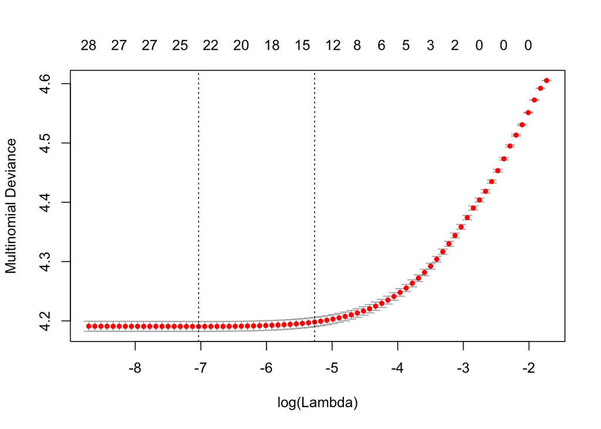

```r
mat_1 <- model.matrix(~ -1 + marg + nivelaprob + marg:nivelaprob,
  data = dat_ing)
mod_decil <- cv.glmnet(y = dat_ing$decil, x = mat_1, alpha  = 0.5,
  family = 'multinomial')
plot(mod_decil)
```

Hacemos las predicciones:

```r
grid_pred <- expand.grid(list(marg = unique(dat_ing$marg),
  nivelaprob = unique(dat_ing$nivelaprob)), stringsAsFactors = FALSE)

mat_pred <- model.matrix(~ -1 + marg + nivelaprob + marg:nivelaprob,
  data = grid_pred)

mod_decil_pred <- predict(mod_decil, s = exp(-4), type = 'response',
  newx =  mat_pred)[, , 1]

dat_pred <- cbind(grid_pred, mod_decil_pred)
head(dat_pred)
```

```
##       marg nivelaprob [ 0.00, 9.05) [ 9.05, 9.40) [ 9.40, 9.66)
## 1 Muy bajo      Prepa         0.039         0.062         0.094
## 2 Muy alto      Prepa         0.252         0.151         0.094
## 3    Medio      Prepa         0.075         0.106         0.129
## 4     Bajo      Prepa         0.071         0.106         0.129
## 5     Alto      Prepa         0.138         0.142         0.116
## 6 Muy bajo   Primaria         0.060         0.088         0.112
##   [ 9.66, 9.88) [ 9.88,10.08) [10.08,10.28) [10.28,10.51) [10.51,10.76)
## 1         0.114         0.120         0.119         0.125         0.118
## 2         0.093         0.084         0.083         0.074         0.070
## 3         0.128         0.116         0.114         0.102         0.097
## 4         0.128         0.116         0.114         0.102         0.097
## 5         0.113         0.102         0.100         0.090         0.080
## 6         0.113         0.119         0.117         0.123         0.113
##   [10.76,11.14) [11.14,14.35]
## 1         0.133         0.075
## 2         0.055         0.044
## 3         0.075         0.060
## 4         0.075         0.060
## 5         0.066         0.053
## 6         0.096         0.059
```

Y ahora podemos examinar cómo están las predicciones del modelo.

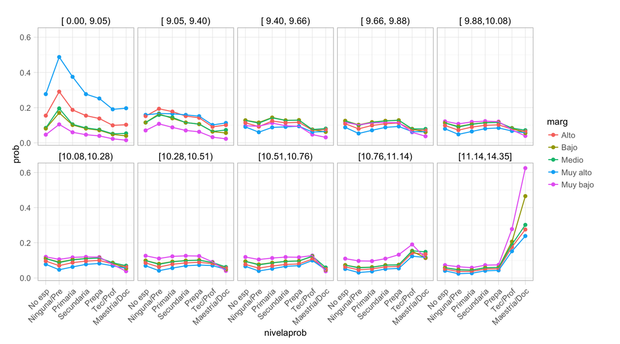

```r
dat_pred_l <- gather(dat_pred, nivel_decil, prob, 3:12)

ggplot(dat_pred_l, aes(x = nivelaprob, y = prob, colour = marg, group = marg)) +
  geom_point() +
  geom_line() +
  facet_wrap(~ nivel_decil, nrow=2) +
  theme(axis.text.x = element_text(angle = 45, hjust = 1))
```

```r
colnames(dat_pred_l)[3] <- "decil"
tab_decil <- xtabs(prob ~ decil + marg + nivelaprob, data = dat_pred_l)
tab_veh
```

```
## , , nivelaprob = No esp, sexojefe = 1
##
##         decil
## vehiculo [ 0.00, 9.05) [ 9.05, 9.40) [ 9.40, 9.66) [ 9.66, 9.88)
##    FALSE        0.4597        0.2400        0.1918        0.1718
##    TRUE         0.5403        0.7600        0.8082        0.8282
##         decil
## vehiculo [ 9.88,10.08) [10.08,10.28) [10.28,10.51) [10.51,10.76)
##    FALSE        0.1116        0.0942        0.0681        0.0514
##    TRUE         0.8884        0.9058        0.9319        0.9486
##         decil
## vehiculo [10.76,11.14) [11.14,14.35]
##    FALSE        0.0348        0.0209
##    TRUE         0.9652        0.9791
##
## , , nivelaprob = Ninguna/Pre, sexojefe = 1
##
##         decil
## vehiculo [ 0.00, 9.05) [ 9.05, 9.40) [ 9.40, 9.66) [ 9.66, 9.88)
##    FALSE        0.9875        0.9670        0.9565        0.9506
##    TRUE         0.0125        0.0330        0.0435        0.0494
##         decil
## vehiculo [ 9.88,10.08) [10.08,10.28) [10.28,10.51) [10.51,10.76)
##    FALSE        0.9209        0.9060        0.8713        0.8340
##    TRUE         0.0791        0.0940        0.1287        0.1660
##         decil
## vehiculo [10.76,11.14) [11.14,14.35]
##    FALSE        0.7696        0.6645
##    TRUE         0.2304        0.3355
##
## , , nivelaprob = Primaria, sexojefe = 1
##
##         decil
## vehiculo [ 0.00, 9.05) [ 9.05, 9.40) [ 9.40, 9.66) [ 9.66, 9.88)
##    FALSE        0.9752        0.9358        0.9164        0.9055
##    TRUE         0.0248        0.0642        0.0836        0.0945
##         decil
## vehiculo [ 9.88,10.08) [10.08,10.28) [10.28,10.51) [10.51,10.76)
##    FALSE        0.8530        0.8278        0.7714        0.7147
##    TRUE         0.1470        0.1722        0.2286        0.2853
```

[output cut: 154 more lines]

```
##
## , , nivelaprob = Maestría/Doc, sexojefe = 2
##
##         decil
## vehiculo [ 0.00, 9.05) [ 9.05, 9.40) [ 9.40, 9.66) [ 9.66, 9.88)
##    FALSE        0.9447        0.9263        0.7489        0.6880
##    TRUE         0.0553        0.0737        0.2511        0.3120
##         decil
## vehiculo [ 9.88,10.08) [10.08,10.28) [10.28,10.51) [10.51,10.76)
##    FALSE        0.6643        0.5548        0.4773        0.4056
##    TRUE         0.3357        0.4452        0.5227        0.5944
##         decil
## vehiculo [10.76,11.14) [11.14,14.35]
##    FALSE        0.2697        0.1745
##    TRUE         0.7303        0.8255
```

```r
fit_enigh_b[['decil']] <- tab_decil
```

Exporta la red a SAMIAM y compara con la red que usó MLE.